# EasyVisa Project

Hyperparameter Tuning - Bagging Classifier

```python
# Defining bagging tuned classifier.
bagging_estimator_tuned = BaggingClassifier(random_state=1)

# Grid of parameters to choose from
parameters = {
    "max_samples": [0.7, 0.8],
    "max_features": [0.3,0.5,0.7,1],
    "n_estimators": np.arange(50,101,25)
}

# Type of scoring used to compare parameter combinations
acc_scorer = metrics.make_scorer(metrics.f1_score)

# Run the grid search
grid_obj = GridSearchCV(BaggingClassifier(random_state=1,bootstrap=True), param_grid=parameters, scoring = acc_scorer, cv = 5)

##fitting the grid_obj on train data
grid_obj = grid_obj.fit(X_train, Y_train)

# Set the clf to the best combination of parameters
bagging_estimator_tuned = grid_obj.best_estimator_

# Fit the best algorithm to the data.
bagging_estimator_tuned.fit(X_train, Y_train)
```

```
BaggingClassifier(max_features=0.7, max_samples=0.7, n_estimators=100,
                  random_state=1)
```

Checking model performance on train and test data set

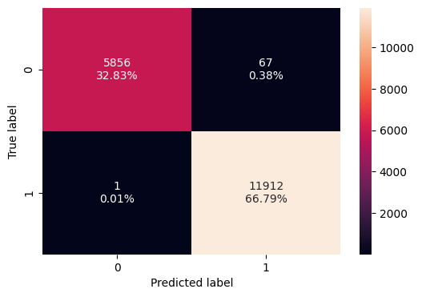

```python
## Checking Confusion matrix for train data on tuned estimator
confusion_matrix_sklearn(bagging_estimator_tuned, X_train, Y_train)
```

```python
## Checking performance for train data on tuned estimator
bagging_estimator_tuned_model_train_perf = model_performance_classification_sklearn(bagging_estimator_tuned, X_train, Y_train)
bagging_estimator_tuned_model_train_perf
```

|  | Accuracy | Recall | Precision | F1 |
| --- | --- | --- | --- | --- |
| 0 | 0.996187 | 0.999916 | 0.994407 | 0.997154 |

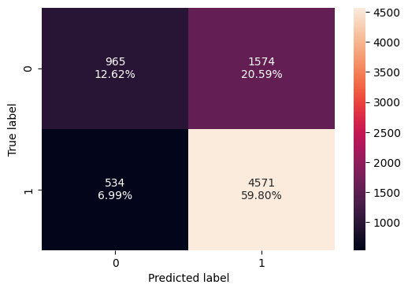

```python
## Checking Confusion matrix for test data on tuned estimator
confusion_matrix_sklearn(bagging_estimator_tuned, X_test, Y_test)
```

```python
## Checking performance for test data on tuned estimator
bagging_estimator_tuned_model_test_perf = model_performance_classification_sklearn(bagging_estimator_tuned, X_test, Y_test)
bagging_estimator_tuned_model_test_perf
```

|  | Accuracy | Recall | Precision | F1 |
| --- | --- | --- | --- | --- |
| 0 | 0.724228 | 0.895397 | 0.743857 | 0.812622 |

- The discrepancy between the F1 scores on the test and train sets is still exists, where the model is doing quite well on the training data and not generalizing well to unseen data, after hyper tuning model performance in test data is slightly improved but the is huge difference in F1 scope for Train and test data.
- Lets check other models and see if we have improvement in prediction of our dependent variable

Let's move to random forest model and check how is the performance on data set

```python
# Fitting the Random Forest model with random state = 1 and class_weight = balanced
rf_estimator = RandomForestClassifier(class_weight="balanced", random_state=1)

##fitting random forest on the train data
rf_estimator.fit(X_train, Y_train)
```

```
RandomForestClassifier(class_weight='balanced', random_state=1)
```

Checking model performance on train and test data set

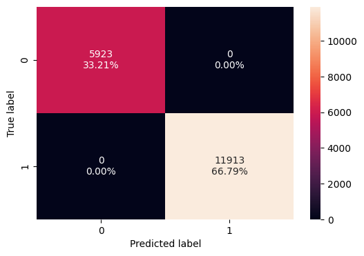

```python
## Checking Confusion matrix for train data on random forest estimator
confusion_matrix_sklearn(rf_estimator, X_train, Y_train)
```

```python
## Check performance on train data
rf_estimator_model_train_perf = model_performance_classification_sklearn(rf_estimator, X_train, Y_train)
rf_estimator_model_train_perf
```

|  | Accuracy | Recall | Precision | F1 |
| --- | --- | --- | --- | --- |
| 0 | 1.0 | 1.0 | 1.0 | 1.0 |

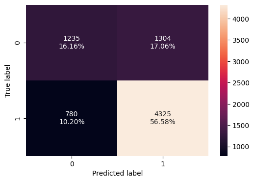

```python
## Complete the code to create confusion matrix for test data
confusion_matrix_sklearn(rf_estimator, X_test, Y_test)
```

```python
## Checking performance for test data
rf_estimator_model_test_perf = model_performance_classification_sklearn(rf_estimator, X_test, Y_test)
rf_estimator_model_test_perf
```

|  | Accuracy | Recall | Precision | F1 |
| --- | --- | --- | --- | --- |
| 0 | 0.727368 | 0.847209 | 0.768343 | 0.805851 |

- The discrepancy between the F1 scores on the test and train sets is indication of overfitting, where the model is too specialize on the training data and not generalizing well to unseen data.

Hyperparameter Tuning - Random Forest

```python
# Defining random forest tuned classifier.
rf_tuned = RandomForestClassifier(random_state=1, oob_score=True, bootstrap=True)

parameters = {
    "max_depth": list(np.arange(5, 15, 5)),
    "max_features": ["sqrt", "log2"],
    "min_samples_split": [3, 5, 7],
    "n_estimators": np.arange(10, 40, 10),
}

# Type of scoring used to compare parameter combinations
acc_scorer = metrics.make_scorer(metrics.f1_score)

# Run the grid search  with cv = 5 and n_jobs = -1
grid_obj = GridSearchCV(rf_estimator, parameters, scoring=acc_scorer, n_jobs= -1, cv=5)

## Fitting the grid_obj on the train data
grid_obj = grid_obj.fit(X_train, Y_train)

# Set the clf to the best combination of parameters
rf_tuned = grid_obj.best_estimator_

# Fit the best algorithm to the data.
rf_tuned.fit(X_train, Y_train)
```

```
RandomForestClassifier(class_weight='balanced', max_depth=10,
                       min_samples_split=3, n_estimators=30, random_state=1)
```

Checking model performance on train and test data set

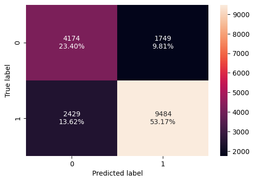

```python
## Creating confusion matrix for train data on tuned estimator
confusion_matrix_sklearn(rf_tuned, X_train, Y_train)
```

```python
## Checking performance for train data on tuned estimator
rf_tuned_model_train_perf = model_performance_classification_sklearn(rf_tuned, X_train, Y_train)
rf_tuned_model_train_perf
```

|  | Accuracy | Recall | Precision | F1 |
| --- | --- | --- | --- | --- |
| 0 | 0.765755 | 0.796105 | 0.844298 | 0.819494 |

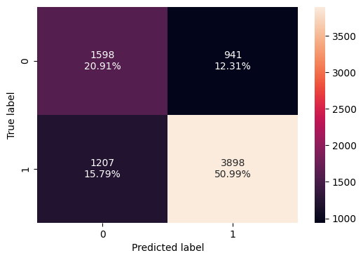

```python
## Creating confusion matrix for test data on tuned estimator
confusion_matrix_sklearn(rf_tuned, X_test, Y_test)
```

```python
## Checking performance for test data on tuned estimator
rf_tuned_model_test_perf = model_performance_classification_sklearn(rf_tuned, X_test, Y_test)
rf_tuned_model_test_perf
```

|  | Accuracy | Recall | Precision | F1 |
| --- | --- | --- | --- | --- |
| 0 | 0.718995 | 0.763565 | 0.805538 | 0.78399 |

- F1 Scope is slightly degraded on test data as compared to random forest initial model, however the F1 score looks gernalised on test data, As The difference of F1 scope values on test and train data is quite low as compare to initial model on default parameters.